# R Notebook

```python
print(4,5)
```

```r
quit
example_vector <- c(10, 20, 30)

example_list <- list(a = 10, b = 20, c = 30)
print(example_vector)
```

[1] 10 20 30

```r
print("-----------------")
```

[1] “—————–”

```r
print(example_list)
```

$a [1] 10

$b [1] 20

$c [1] 30

```r
cat("vector",example_vector[1])
```

vector 10

```r
cat("\n list",example_list[['a']])
```

list 10

```r
cat("\n An element",example_list$b)
```

An element 20

```r
ex.a=12
print(ex.a)
```

[1] 12

```r
ex_vec<- c('a',1,T)
print(ex_vec)
```

[1] “a” “1” “TRUE”

```r
cat("\n")
```

```r
ex_vector<-c(s='dj',1, c(1,23,44))
print(ex_vector);
```

s  
“dj” “1” “1” “23” “44”

```r
print("Hello, World!")
```

[1] “Hello, World!”

```r
list1<-list(1,"a",Sys.time())
print(list1)
```

[[1]] [1] 1

[[2]] [1] “a”

[[3]] [1] “2025-07-25 12:41:00 IST”

```r
list2<-list(a=1,b='a',c=Sys.time())
print(list2)
```

$a [1] 1

$b [1] “a”

$c [1] “2025-07-25 12:41:00 IST”

```r
list2$a
```

[1] 1

```r
list2[['a']]
```

[1] 1

```r
list2[[1]]
```

[1] 1

```r
8 < 4
```

[1] FALSE

```r
3 * 2 == 6
```

[1] TRUE

```r
x <- c(1:10)

x
```

[1] 1 2 3 4 5 6 7 8 9 10

```r
x>7
```

[1] FALSE FALSE FALSE FALSE FALSE FALSE FALSE TRUE TRUE TRUE

```r
x<5
```

[1] TRUE TRUE TRUE TRUE FALSE FALSE FALSE FALSE FALSE FALSE

```r
x>7 & x<5
```

[1] FALSE FALSE FALSE FALSE FALSE FALSE FALSE FALSE FALSE FALSE

```r
x[x>7 | x<5]
```

[1] 1 2 3 4 8 9 10

```r
Sys.Date()
```

[1] “2025-07-25”

```r
Sys.time()
```

[1] “2025-07-25 12:41:00 IST”

```r
Sys.timezone()
```

[1] “Asia/Kolkata”

```r
today <- Sys.Date()
today
```

[1] “2025-07-25”

```r
format(today,format='%B %d %Y')
```

[1] “July 25 2025”

```r
format(today,format='%b %d %Y')
```

[1] “Jul 25 2025”

```r
format(today,format='%m %d %Y')
```

[1] “07 25 2025”

```r
format(Sys.time(), "%A, %B %d, %Y at %I:%M %p")
```

[1] “Friday, July 25, 2025 at 12:41 PM”

```r
customdate="22-7-25"
class(customdate)
```

[1] “character”

```r
cd=as.Date(customdate)
cd
```

[1] “22-07-25”

```r
typeof(cd)
```

[1] “double”

```r
class(cd)
```

[1] “Date”

```r
x<-Sys.time()
class(x)

strDates<-c('8/15/1947', '7/22/2025')


dates=as.Date(strDates, "%m /%d /%Y")
```

[output not shown]

```r
dates
dates[2]-dates[1]
```

[output not shown]

```r
t=sum(2,3,4)
print(t)

#NA stands for "Not Available."
#NaN stands for "Not a Number."
sum(1,5,NA)

sum(1,5,NaN,1)

sum(1, 5, NA, NaN, na.rm=TRUE)
```

[output not shown]

seq() function

```r
# seq(start from, to, by, length.out)
seq(1,10,2)
seq(1,20,length.out=10)
seq(18)

seq(5, 10)

seq(10, 1)

seq(1,6,by=3)
```

[output not shown]

```r
rep (3, 4)
```

[1] 3 3 3 3

```r
# 3 3 3 3

x <-rep (3, 4)
x
```

[1] 3 3 3 3

```r
rep("ab",3)
```

[1] “ab” “ab” “ab”

```r
a=c("aa","bb")
print(a)
```

[1] “aa” “bb”

```r
strsplit(a,"" )
```

[[1]] [1] “a” “a”

[[2]] [1] “b” “b”

String manipulation

```r
strsplit(a, " ")
```

[[1]] [1] “aa”

[[2]] [1] “bb”

```r
grep("ness","business")
```

[1] 1

```r
grep("s","business")
```

[1] 1

```r
grep("as","business")
```

integer(0)

In the example below, the function grep() finds the index position at which the string, ‘statistical’ is present

```r
print(grep('statistical',c('R','is','a','statistical','language'),fixed=FALSE))
```

[1] 4

```r
print(grep('tat',c('R','is','a','statistical','language'),fixed=FALSE))
```

[1] 4

```r
toupper('statistics')
```

[1] “STATISTICS”

```r
# or
casefold('statistics',upper=TRUE)
```

[1] “STATISTICS”

```r
casefold('Statistics')
```

[1] “statistics”

substr() function extracts or replaces substrings in a character vector. Syntax substr(x, start, stop)

```r
substr('statistics', 7, 9)
```

[1] “tic”

```r
A<-c(10,20,NA,40)
A
```

[1] 10 20 NA 40

```r
is.na(A)
```

[1] FALSE FALSE TRUE FALSE

```r
B<-c(na.omit(A))
B
```

[1] 10 20 40

```r
d<-c(na.exclude(A))
d
```

[1] 10 20 40

```r
a<-c(1,2)
e<-c(na.pass(a))
e
```

[1] 1 2

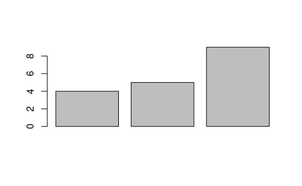

```r
barVector<-c(4,5,9)
barplot(barVector)
```

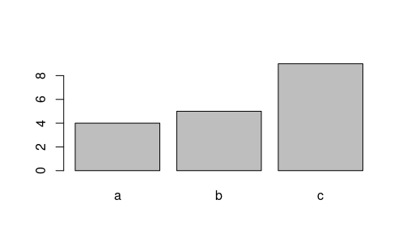

```r
names(barVector)<-c('a','b','c')
barplot(barVector)
```

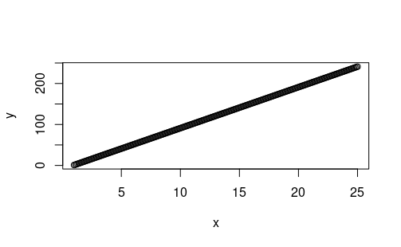

```r
x<-seq(1,25,0.1)
y<-seq(x)
plot(x,y)
```

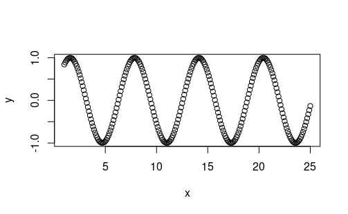

```r
y<-sin(x)
plot(x,y)
```

```r
# Create a data frame named 'Employees' with details of 5 employees
Employees = data.frame(
  # Employee names
  Name = c("Anastasia S", "Dima R", "Katherine S", "JAMES A", "LAURA MARTIN"),
  # Employee genders
  Gender = c("M", "M", "F", "F", "M"),
  # Employee ages
  Age = c(23, 22, 25, 26, 32),
  # Employee designations
  Designation = c("Clerk", "Manager", "Exective", "CEO", "ASSISTANT"),
  # Employee Social Security Numbers (SSN)
  SSN = c("123-34-2346", "123-44-779", "556-24-433", "123-98-987", "679-77-576")
)

# Print a message indicating the summary of the data
print("Summary of the data:")
```

[1] “Summary of the data:”

```r
# Print a summary of the 'Employees' data frame, which includes basic statistics
print(summary(Employees))
```

```
 Name              Gender               Age       Designation
```

Length:5 Length:5 Min. :22.0 Length:5  
Class :character Class :character 1st Qu.:23.0 Class :character  
Mode :character Mode :character Median :25.0 Mode :character  
Mean :25.6  
3rd Qu.:26.0  
Max. :32.0  
SSN  
Length:5  
Class :character  
Mode :character

```r
edit(Employees)
```

Error in edit : Editing of data frames and matrixes is not supported in RStudio.

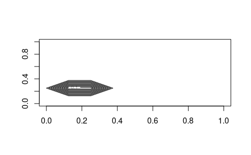

```r
mat <- matrix(1, 9, 9)
mat[3,3]<-0
mat[2,3]<-0
contour(mat)
```

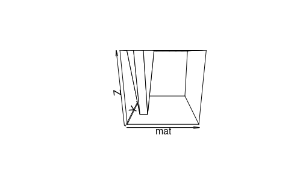

```r
persp(mat)
```

```r
dim(volcano)
```

[1] 87 61

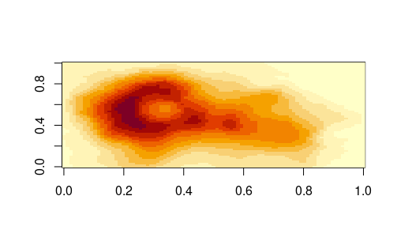

```r
a=volcano
#View(volcano)
image(volcano)
```

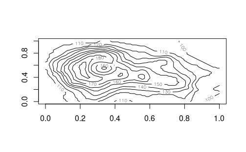

```r
contour(volcano)
```

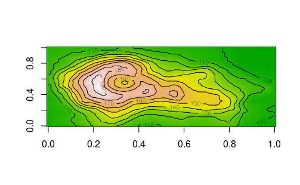

```r
image(volcano, col = terrain.colors(100))
contour(volcano, add = TRUE)
```

R’s basic data types are Numeric, character, integer, factor and logical (True, False)

```r
music_vector<-c("Jazz", "Rock", "Classic", "Classic", "Pop", "Jazz", "Rock", "Jazz")
music_genre <- factor(c("Jazz", "Rock", "Classic", "Classic", "Pop", "Jazz", "Rock", "Jazz"))
as.integer(music_genre)
```

[1] 2 4 1 1 3 2 4 2

```r
as.integer(music_vector)
```

[1] NA NA NA NA NA NA NA NA

```r
class(music_genre)
```

[1] “factor”

```r
x <- c("Low", "Medium", "High", "Medium", "Low")
just_factor<-factor(x)
ordered_x <- factor(x, levels = c("Low", "Medium", "High"), ordered = FALSE)
print("ordered x is")
```

[1] “ordered x is”

```r
print(ordered_x)
```

[1] Low Medium High Medium Low  
Levels: Low Medium High

```r
print(as.integer(ordered_x))
```

[1] 1 2 3 2 1

```r
print("just factor is ")
```

[1] “just factor is”

```r
print(just_factor)
```

[1] Low Medium High Medium Low  
Levels: High Low Medium

```r
print(as.integer(just_factor))
```

[1] 2 3 1 3 2

```r
print("-----------------------------------------")
```

[1] “—————————————–”

```r
print(as.integer(ordered_x))
```

[1] 1 2 3 2 1

```r
print(max(ordered_x))
```

Error in h(simpleError(msg, call)) : error in evaluating the argument ‘x’ in selecting a method for function ‘print’: ‘max’ not meaningful for factors

```r
library(Matrix)
names(Orange)
```

[1] “Tree” “age” “circumference”

```r
print("------------------------------")
```

[1] “——————————”

```r
summary(Orange)
```

Tree age circumference  
3:7 Min. : 118.0 Min. : 30.0  
1:7 1st Qu.: 484.0 1st Qu.: 65.5  
5:7 Median :1004.0 Median :115.0  
2:7 Mean : 922.1 Mean :115.9  
4:7 3rd Qu.:1372.0 3rd Qu.:161.5  
Max. :1582.0 Max. :214.0

```r
print("------------------------------")
```

[1] “——————————”

```r
str(Orange)
```

Classes ‘nfnGroupedData’, ‘nfGroupedData’, ‘groupedData’ and ‘data.frame’: 35 obs. of 3 variables: $ Tree : Ord.factor w/ 5 levels “3”<“1”<“5”<“2”<..: 2 2 2 2 2 2 2 4 4 4 … $ age : num 118 484 664 1004 1231 … $ circumference: num 30 58 87 115 120 142 145 33 69 111 … - attr(*, “formula”)=Class ‘formula’ language circumference ~ age | Tree .. ..- attr(*, “.Environment”)=<environment: R_EmptyEnv> - attr(*, “labels”)=List of 2 ..$ x: chr “Time since December 31, 1968” ..$ y: chr “Trunk circumference” - attr(*, “units”)=List of 2 ..$ x: chr “(days)” ..$ y: chr “(mm)”

```r
print(Orange$Tree)
```

[1] 1 1 1 1 1 1 1 2 2 2 2 2 2 2 3 3 3 3 3 3 3 4 4 4 4 4 4 4 5 5 5 5 5 5 5 Levels: 3 < 1 < 5 < 2 < 4

```r
print("------------------------------")
```

[1] “——————————”

```r
table(Orange$Tree)
```

3 1 5 2 4 7 7 7 7 7